# Basic slideshow with R markdown

17 February 2017

## Making a slide show

Two hashtags makes a new slide.

You will want to set up a project folder for you slideshow, adding in scripts, images, etc.

## The YAML is your 1st slide, you can customize it!

output: ioslides_presentation:

```
css: wtc_custom.css

logo: images/hielogo.png

smaller: yes

transition: faster

widescreen: yes
```

If you do not want to include author/date just delete it or use ""

## Slide with Bullets

- You can run the slideshow 'live' from you computer once you knit
- You can click on "open in browser" to view it as a web presentation
- You can publish it to Rpubs for free
- You can use the rendered html file anytime/anywhere (if show is static)

## Use HTML tags to space text objects

- You can run the slideshow 'live' from you computer once you knit
- You can click on "open in browser" to view it as a web presentation

## Slide with animated bullets

- There are a quite a few good websites to help you learn the basics
- There is a rstudio cheatsheat that you should print out for basic commands
- https://www.rstudio.com/wp-content/uploads/2015/02/rmarkdown-cheatsheet.pdf
- http://rmarkdown.rstudio.com/ioslides_presentation_format.html

## Easily insert images (1)

[figure not shown]

You just need to know the filepath to your image

## Easily insert images (2)

You have some control of image placement, but not much

[figure not shown]

## Better image placement with CSS

[figure not shown]

## Basic text control is pretty easy

- **You can use markdown language or HTML tags**
- I study how elevated CO<sub>2</sub> impacts the physiology of *Cephalodesmius armiger*
- My research is **AWESOME**!!

[figure not shown]

## Seperate the slide titles from the body

For that just use the horizontal rule HTML tag

## Inserting plots (1) Ive already made it

[figure not shown]

## Inserting plots (2) Use code chunks

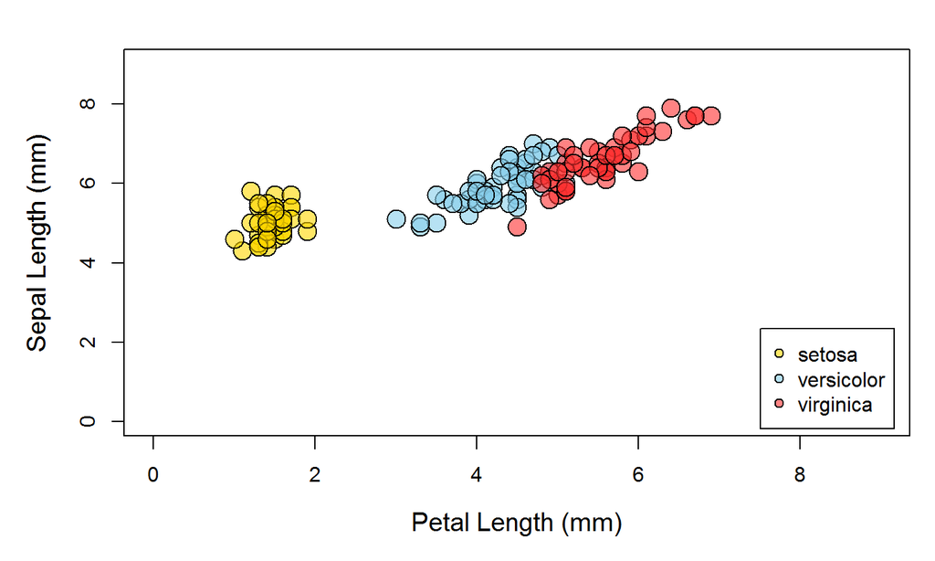

## Inserting plots (3) Source scripts

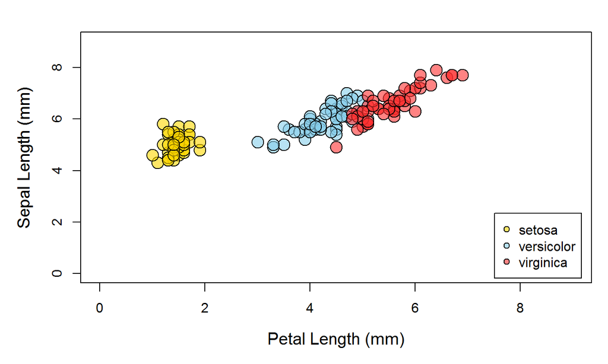

## Tables can be done too!

| Species | Sepal.Length | Sepal.Width | Petal.Length | Petal.Width |
| --- | --- | --- | --- | --- |
| setosa | 5.006 | 3.428 | 1.462 | 0.246 |
| versicolor | 5.936 | 2.770 | 4.260 | 1.326 |
| virginica | 6.588 | 2.974 | 5.552 | 2.026 |

[figure not shown]

## xtable examples

|  | Estimate | Std. Error | t value | Pr(>\|t\|) |
| --- | --- | --- | --- | --- |
| (Intercept) | -0.06 | 0.11 | -0.5 | 0.63 |
| x | 1.95 | 0.11 | 17.3 | 0.00 |

There are several packages to make tables, they each allow different levels of customization